# Performance Comparison Between Didfferent Data Processing Approaches for Flight Ticket Data

Jun Cai & Vikas Boddu

Feb 06, 2016

### Conclusion

In the analysis of our graph we can draw upon many conclusions from this project.

As expected, the multi-threaded implementations showed performance gains over their single-threaded counterparts.

It can also be seen that the duration of fast median is almost an exact copy of the true median. This shows that our implementation of fast median is not an ideal one.

Another conclusion is that our EMR implementations stand out compared to the others i.e. EMR is extremely slow comparatively. This can be explained due to the large overhead in setting up a cluster on EMR. Perhaps if our data set was multiple factors larger, then we could see performance benefits on this implementation.

Similarly, the pseudo-distributed mode took longer as well compared to our single and multi threaded implementations. This could be explained due to the overhead of hadoop as well.

The format of the input data is compressed csv files. These gzipped files are store in the ‘input’ folder residing in HDFS under pseudo-distributed mode and in S3 bucket under cluster mode. Since the HDFS can automatically handle the decompressing of the gzipped file, there is no need to explicitly write code for that. The unzipped csv files will be the input of the Mapreduce. They will be read as a text file. Each line is parsed as a record using a simplified csv format parser.

Following is the result graph created by R script.

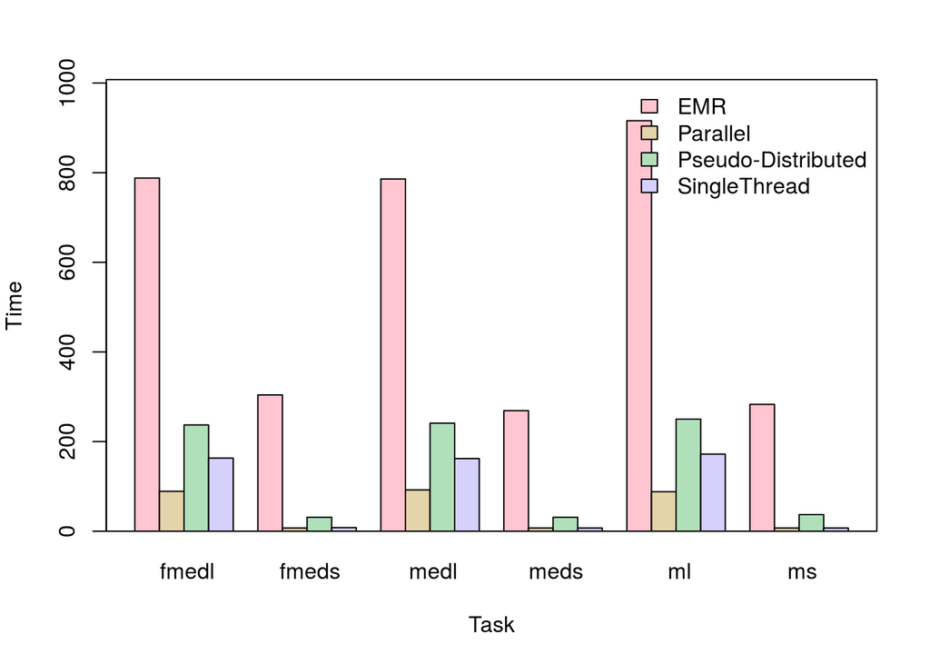